# ESM 206 Assignment 5

Zoe Duerksen-Salm & Audrey Nolan

11/23/2019

### to work on:

- add in PGS photo
- add map of the area
- add meaningful titles

### Introduction

- 7-8 sentences for reader to understnad purpose of report
- image of pacific giant salamander (with credit to author/photographer)

(! this syntax is SoOoO STALE, HALP ! (but the info is good))

Pacific Giant Salamander (Dicamptodon tenebrosus) populations range from northern California to the Canadian border, but are absent from the Olympic Peninsula. Pacific Giant Salamanders(PGS) habitats consist of wetlands such as permanent rivers, streams, creeks and pools of forests<sup>[1](https://www.iucnredlist.org/species/59081/78906025#habitat-ecology)</sup>. PGS are the largest terrestrial salamander in North America, growing up to 13 inches in total length <sup>[2](http://www.californiaherps.com/salamanders/pages/d.tenebrosus.html)</sup>. PGS populations may be affected by increases in pressures associated with logging such as a decrease in habitat and an increase in siltation of the water due to upstream disturbances. This report analyses the differences in PGS populations between old growth(OG) forests and clear cut (CC) forests located in the H.J. Andrews Experimental Forest.

### Data and Methods

The data<sup>[3](https://doi.org/10.6073/pasta/5de64af9c11579266ef20da2ff32f702)</sup> analyzed for this report was collected from Mack Creek in the H.J. Andrews Experimental Forest in Oregon. Cuttthroat trout (Onchorhyncus clarki clarki) populations have been monitored since 1987 then monitoring of Pacific Giant Salamanders began in 1993. H.J. Andrews Experimental Forest contains two sections of clearcut forest (cleared in 1963) and an upstream 500 year old coniferous forest. These two sections will be referred to as “clear-cut”(CC) and “old-growth”(OG) throughout this report. Specimen were sampled via electro-fishing and captured vertebrates were measured and weighed. This report uses the salamander data regarding section (old growth or clearcut), channel-specification (cascades, pool or side-channel), salamander weight (grams), and total salamander counts observed(n).

### Results

#### Results A:

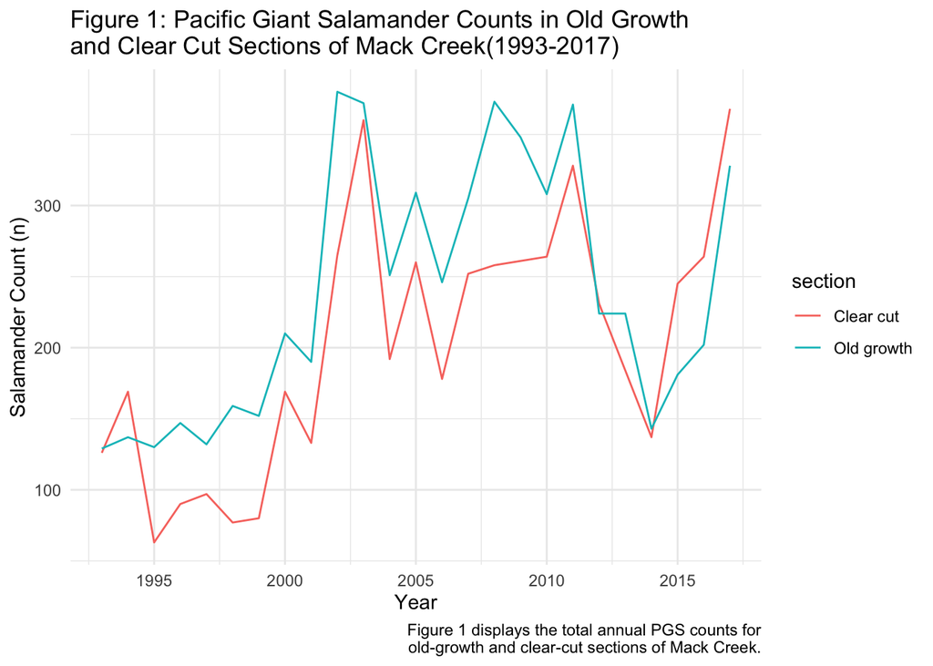

#### Results B:

Pacific giant salamander observations from 2017 were [compiled] to evaluate salamander counts and proportions in different channel classifications (pool, cascade, or side-channel) within Mack Creek for the two sections (old growth and clear cut).

Talbe 1 [indicates] that the majority of salamanders observed in both clear cut and old growth forest sections were found in cascades (over 60% for both). Side channels [contained] the [second most] observatoins (between 23-24% of observations). The [lowest] proportion of salamanders were observed in pools (less than 15% of relative abundance). Overall, more salamanders were observed in clear cut than old growth sections–368 and 320 respectively.

Table 1 [displays] the 2017 salamander counts in each section and the relative proportions of salamanders in each channel classification(cascade, pool or side-channel)

| Section | Cascades | Pool | Side-channel |
| --- | --- | --- | --- |
| Clear cut | 247 (67%) | 31 (8%) | 90 (24%) |
| Old growth | 201 (63%) | 45 (14%) | 74 (23%) |

#### Results C:

A chi-square test was used to determine if there is an association between forest secction (clear cut or old growth) and channel classification (cascades, pool, or side channel). The results indicate that forest section does not have a significatn effect on salamander location, and are thus independnet of each other ($\chi$<sup>2</sup>(2) = 5.54, *p* = 0.06).

#### Results D:

PGS mean weight is 1.08 grams greater in clear cut sections than in old growth (7.78g and 6.7g, respectively). The results indicate that there *is not* a significant difference in *mean* weights for Pacific giant salamanders observed in the two forest sections (t(683.21) = (1.49, *p* = (0.138).

Large sample size, a lack of significance difference between sample means, and a small effect size (Cohen’s d = 0.11) indicates a lack of association between PGS weight and forest condition.

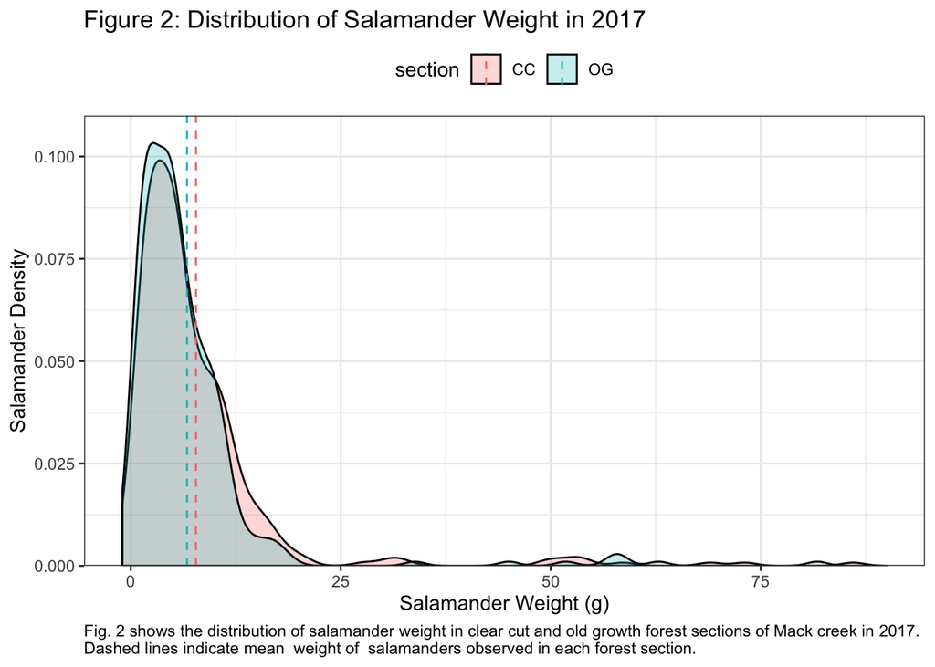

#### Results E:

Compare weights of Pacific giant salamanders in pools, cascades and side-channels of Mack Creek in 2017. Pool salamander observations from both the old growth and clear cut sections for this part (i.e., you will not consider “section” as a factor here).

[figure not shown]

| unittype | mean_weight | sd_weight | sample_size | se_weight | var_weight |
| --- | --- | --- | --- | --- | --- |
| C | 7.520850 | 9.027747 | 448 | 0.4265209 | 81.50021 |
| P | 9.297500 | 13.622957 | 76 | 1.5626603 | 185.58494 |
| SC | 5.676646 | 8.265256 | 164 | 0.6454081 | 68.31446 |

### References

1. https://www.iucnredlist.org/species/59081/78906025#habitat-ecology
2. http://www.californiaherps.com/salamanders/pages/d.tenebrosus.html The historical distribution of this slamander has probably not declined, though there certainly has been some localized extirpation from urbanization and some fragmentation within the range mostly due to forestry practices. Studies indicate a long-term decline in populations after logging of old-growth forests. D. ensatus is far more abundant in unsilted streams than in streams that have become silted due to logging or other alteration of the land above the stream. Creek sedimentation eliminates access to cover under rocks in the streambed which is critical habitat
3. Gregory S. V. 2016. Aquatic Vertebrate Population Study in Mack Creek, Andrews Experimental Forest, 1987 to present. Environmental Data Initiative. https://doi.org/10.6073/pasta/5de64af9c11579266ef20da2ff32f702. Dataset accessed 12/01/2019.